# Hogan CKMRSIM

```r
source("C:/Users/ealescak/Documents/R/functions.gcl.r")
```

[output not shown]

[output cut: 23 more lines]

```r
load_sillys(path = "V:/Analysis/5_Coastwide/Multispecies/Alaska Hatchery Research Program/PWS Pink/Genotypes/OceanAK_Origin_PostQA/")
```

```
[1] "PHOGAN13h" "PHOGAN13n" "PHOGAN14h" "PHOGAN14n" "PHOGAN15"  "PHOGAN16"
```

```r
.username <- "ealescak"
.password <- "1234"
markersuite <- "Pink_PWS_304"
CreateLocusControl.GCL(markersuite = markersuite, username = .username, password = .password)
```

```
[1] "LocusControl created for markersuite='Pink_PWS_304'"
```

```r
loci <- LocusControl$locusnames
nalleles <- LocusControl$nalleles
ploidy <- LocusControl$ploidy
alleles <- LocusControl$alleles
PoolCollections.GCL(collections = c("PHOGAN13h", "PHOGAN13n"), loci = loci, newname = "PHOGAN13_postQA")
```

```r
PoolCollections.GCL(collections = c("PHOGAN14h", "PHOGAN14n"), loci = loci, newname = "PHOGAN14_postQA")
```

# Odd

```r
dose1 <- PHOGAN13_postQA.gcl$scores[,,1] %>%
  as_tibble(rownames="ind") %>%
  gather(locus, dose1, -ind)
dose2 <- PHOGAN13_postQA.gcl$scores[,,2] %>%
  as_tibble(rownames="ind") %>%
  gather(locus, dose2, -ind)
Hogan_13_input <- left_join(dose1, dose2, by = c("ind", "locus"))
```

### Computing allele frequencies

```r
#haptidy <- hapkept %>%
#  unite(col = hap1, haplotype.1, read.depth.1) %>%
#  unite(col = hap2, haplotype.2, read.depth.2) %>%
#  gather(key = gene_copy, value = H, hap1, hap2) %>%
#  separate(H, into = c("Allele", "read_depth")) %>%
#  arrange(panel, locus, Indiv.ID, gene_copy)
haptidy_13 <- Hogan_13_input %>%
  gather(key = gene_copy, value = H, dose1, dose2) %>%
  separate(H, into = "Allele") %>%
  arrange(locus, ind, gene_copy)
```

So, now we just need to compute the frequencies for each of the haplotypes

```r
hapfreqs_13 <- haptidy_13 %>%
  group_by(locus, Allele) %>%
  summarise(count = n()) %>%
  mutate(Freq = count / sum(count))
```

## Do the CKMR sim analyses

### Get it in the right format

First we have to get that data frame in the right format and reindex the markers and make something that `CKMRsim` is expecting to be able to work with (i.e., it has haplotypes in descending frequeny at each locus and it has locus and allele indices in there). To get loci to be ordered as they are, I have to throw `Pos` in there, even though they are not known to have a position on any Chrom.

```r
mhaps_13 <- hapfreqs_13 %>%
  ungroup() %>%
  mutate(Chrom = "GTseq") %>%
  rename(Locus = locus) %>%
  select(-count) %>%
  mutate(Pos = as.integer(factor(Locus, levels = unique(Locus)))) %>%
  mutate(LocIdx = 0,
         AlleIdx = 0) %>%
  CKMRsim::reindex_markers() %>%
  select(Chrom, Locus, Pos, Allele, LocIdx, AlleIdx, Freq)
```

### Make Figure 1.

While we are at it, let’s look at the distribution of the number of alleles across loci:

```r
m_13 <- mhaps_13 %>%
  group_by(Locus) %>%
  summarise(num_haplotypes = n()) %>%
  group_by(num_haplotypes) %>%
  summarise(num_loci = n()) %>% # plot this for figure 1
  ggplot(., aes(num_haplotypes, num_loci)) +
  geom_histogram(stat = "identity") +
  theme_bw() +
  xlab("Number of Haplotypes") +
  ylab("Number of Loci") +
  scale_x_continuous(breaks = c(3,6,9,12))
```

```
Ignoring unknown parameters: binwidth, bins, pad
```

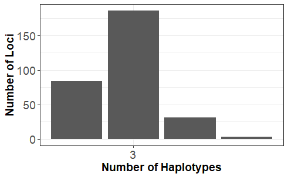

```r
fig1 <- m_13 + theme(
  axis.text.x=element_text(size=14),
  axis.title.x=element_text(size=14, face="bold"),
  axis.text.y=element_text(size=14),
  axis.title.y=element_text(size=14, face="bold")
)
fig1
```

```r
mhaps_13_filter <- mhaps_13 %>%
  filter(Allele != "0")
```